# StatComp Project 1: 3D printer materials estimation

Orlagh Keane (s2084384)

# 1 The Data

To look closely at the variability of CAD_Weight across different materials used in 3D printing I have created the box-plot below. One noticeable observation is the wide range of variability that each material has, which can be seen on from the length of the box plots below, with materials like Red and Neon Blue displaying particularly large IQRs. For instance, Neon blue shows an IQR of 25.5, while Red has an much larger IQR of 64. This indicates that objects printed with these materials can vary significantly in weight. In contrast, Magenta and Neon Pink have relatively narrow IQRs, standing at 4.25 and 6.5, respectively, suggesting a more consistent weight range for objects printed using these materials.

Further analysis of the mean CAD_Weight across different materials highlights additional disparities. Notably, Red, Neon Pink and Magenta exhibit higher mean CAD_Weights compared to other materials, with Red showing a mean of 51.91, Neon Pink a mean of 40.67 and Magenta a mean of 40.20 meanining these tend to be heavier. On the other hand, Neon Pink boasts the smallest standard deviation (SD) of 6.807, indicating lower variability in CAD_Weight around the mean compared to other materials. In contrast, Red has the highest variance at 956.75 signifying a greater degree of variability in CAD_Weight values.

These results are reflected in the graph and table below.

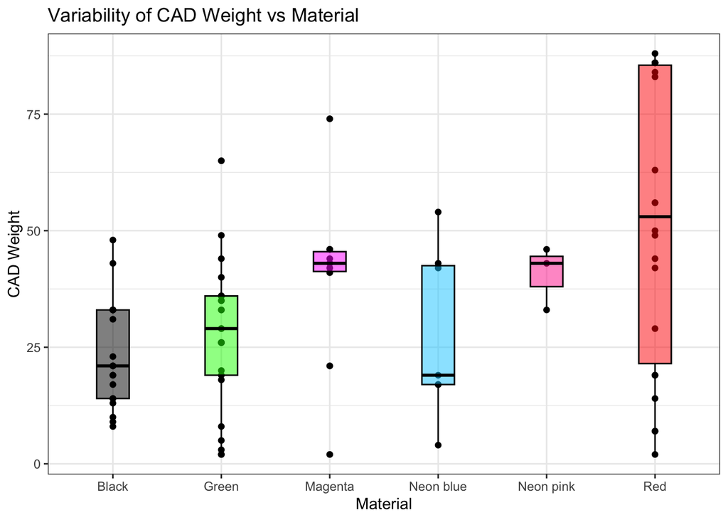

| Material | Mean | IQR | SD | Var |
| --- | --- | --- | --- | --- |
| Black | 23.26316 | 19.00 | 11.584674 | 134.20468 |
| Green | 27.24000 | 17.00 | 15.417198 | 237.69000 |
| Magenta | 40.20000 | 4.25 | 18.474006 | 341.28889 |
| Neon blue | 28.00000 | 25.50 | 18.239152 | 332.66667 |
| Neon pink | 40.66667 | 6.50 | 6.806859 | 46.33333 |
| Red | 51.90909 | 64.00 | 30.931428 | 956.75325 |

# 2 Classical estimation

Since we want to understand the relationship between the calculated weight, CAD_Weight, of an object using CAD software and its actual weight, Actual_Weight, after 3D printing, we will create two linear models, Model A and Model B to capture this relationship.

Model A: y_i ~ Normal[β_1 + β_2x_i, exp(β_3 + β_4x_i)] Model B: y_i ~ Normal[β_1 + β_2x_i, exp(β-3) + exp(β_4)x_i^2]

Model A considers an additive error approximation, the observed weight, y_i, is assumed to follow a Normal distribution with mean β_1 + β_2x_i and standard deviation exp(β_3 + β_4x_i). On the other hand, Model B considers a relative error approximation, where the observed weight follows a Normal distribution with the same mean β_1 + β_2x_i and standard deviation exp(β_3) + exp(β_4)x_i.

From the theory of negative log-likelihood functions, it is known that the expected Hessian is always positive definite, and we can use the observed Hessian H(theta), called Fisher Scoring. We can use this to find the 90% confidence interval as below.The square root of the diagonal elements of S gives the standard errors for each parameter. Lower and upper bounds for the 90% confidence interval are calculated as the estimated value plus or minus the product of the Z-score and the standard error.

```r
# Estimate Model A and B
fit_A <- filament1_estimate(filament1, "A")
fit_B <- filament1_estimate(filament1, "B")

#print(fit_A)
#print(fit_B)

# Calculate standard errors for hessian at A and B
se_A <- sqrt(diag(solve(fit_A$hessian)))
se_B <- sqrt(diag(solve(fit_B$hessian)))

#Calculate z norm for 90% interval
z <- qnorm(0.95)

#Calculate the lower and upper bounds
ci_A <- matrix(NA, nrow = 4, ncol = 2)
ci_B <- matrix(NA, nrow = 4, ncol = 2)

ci_A[,1] <- fit_A$parameters - z * se_A
ci_A[,2] <- fit_A$parameters + z * se_A

ci_B[,1] <- fit_B$parameters - z * se_B
ci_B[,2] <- fit_B$parameters + z * se_B

#Create df for the knitr table
conf_intervals <- data.frame(
  Model = c("A", "B"),
  β_1_Lower = c(ci_A[1,1], ci_B[1,1]),
  β_1_Upper = c(ci_A[1,2], ci_B[1,2]),
  β_2_Lower = c(ci_A[2,1], ci_B[2,1]),
  β_2_Upper = c(ci_A[2,2], ci_B[2,2]),
  β_3_Lower = c(ci_A[3,1], ci_B[3,1]),
  β_3_Upper = c(ci_A[3,2], ci_B[3,2]),
  β_4_Lower = c(ci_A[4,1], ci_B[4,1]),
  β_4_Upper = c(ci_A[4,2], ci_B[4,2])
)


knitr::kable(conf_intervals, caption = "90% Confidence Intervals for Model A and B")
```

90% Confidence Intervals for Model A and B

| Model | β_1_Lower | β_1_Upper | β_2_Lower | β_2_Upper | β_3_Lower | β_3_Upper | β_4_Lower | β_4_Upper |
| --- | --- | --- | --- | --- | --- | --- | --- | --- |
| A | -0.3006372 | 0.1219777 | 1.069471 | 1.088948 | -2.471417 | -1.336143 | 0.0410248 | 0.0703649 |
| B | -0.2215253 | -0.1010437 | 1.075162 | 1.090557 | -98.038348 | 71.035388 | -6.8644413 | -6.3627623 |

For Model A, all confidence intervals are fairly narrow and more centered around the estimates, which indicates that the model has relatively good precision in estimating the parameters. The width of the intervals for β1 and β2 is quite small, indicating higher confidence in the estimates for these parameters.

For Model B, the confidence intervals are much wider, especially for β3 and β4, which indicates a lower precision or less certainty in the parameter estimates.The model might not be as effective in explaining the data or there maybe more significant variations in the data that the model can’t account for.

The confidence intervals for β3 in Model B are so wide that they span a large range of values from -98.038348 to 71.035388, which suggests its unstable and unreliable in the model’s estimation.

# 3 Bayesian estimation

We are using a Bayesian model to describing the actual weight (yi) based on the CAD weight (xi) for an observation i with yi ∼ Normal[β1 + β2xi, β3 + β4x2i ]

Independent prior distributions are assigned to values of theta: θ = [θ1, θ2, θ3, θ4] = [β1, β2, log(β3), log(β4)]

θ1 ∼ Normal(0, γ1) θ2 ∼ Normal(1, γ2) θ3 ∼ LogExp(γ3) θ4 ∼ LogExp(γ4)

Using functions below :

log_prior_density : Uses dnorm and dlogexp to evaluate the log of the joint prior density for the four theta parameters.

The mode, Hessian and S can be seen in the tables below.

```r
# Set starting values for theta and gamma parameters
theta_start <- c(0, 0, 0, 0)
params <- c(1, 1, 1, 1)

# Find posterior mode
post_mode <- posterior_mode(theta_start, filament1$CAD_Weight, filament1$Actual_Weight, params)

# Display posterior mode
mode_result <- post_mode$mode
mode_df <- data.frame(
  theta1 = mode_result[1],
  theta2 = mode_result[2],
  theta3 = mode_result[3],
  theta4 = mode_result[4]
)
rownames(mode_df) <- "mu"
thetas <- c('theta1', 'theta2', 'theta3', 'theta4')
hessian_result <- post_mode$hessian
rownames(hessian_result) <- thetas
colnames(hessian_result) <- thetas

s_result <- post_mode$S
rownames(s_result) <- thetas
colnames(s_result) <- thetas

knitr::kable(mode_df, caption = 'Posterior Mode')
```

Posterior Mode

|  | theta1 | theta2 | theta3 | theta4 |
| --- | --- | --- | --- | --- |
| mu | -0.1007081 | 1.080021 | -2.981786 | -6.75857 |

```r
knitr::kable(hessian_result, caption = 'Hessian')
```

Hessian

|  | theta1 | theta2 | theta3 | theta4 |
| --- | --- | --- | --- | --- |
| theta1 | -238.750166 | -2573.81437 | 2.865874 | -2.742917 |
| theta2 | -2573.814374 | -63698.40393 | -14.451113 | 14.701761 |
| theta3 | 2.865874 | -14.45111 | -1.468185 | -3.658789 |
| theta4 | -2.742917 | 14.70176 | -3.658789 | -32.314181 |

```r
knitr::kable(s_result, caption = 'S matrix')
```

S matrix

|  | theta1 | theta2 | theta3 | theta4 |
| --- | --- | --- | --- | --- |
| theta1 | 0.0083022 | -0.0003433 | 0.0302723 | -0.0042885 |
| theta2 | -0.0003433 | 0.0000300 | -0.0014929 | 0.0002118 |
| theta3 | 0.0302723 | -0.0014929 | 1.0629082 | -0.1235971 |
| theta4 | -0.0042885 | 0.0002118 | -0.1235971 | 0.0454009 |

Below find an example of the values found in the do-importance(). Firstly we construct the 90% Bayesian credible interval for each βj.

```r
# Get the posterior mode
post_mode <- posterior_mode(theta_start, filament1$CAD_Weight, filament1$Actual_Weight, params)

# Extract the mode and the S matrix x, y, and give the N and gamma params
N <- 10000
mu <- post_mode$mode
S <- post_mode$S
x <- filament1$CAD_Weight
y <- filament1$Actual_Weight
params <- c(1, 1, 1, 1)

# Get the importance samples
imp_sample <- do_importance(N, mu, S, x, y, params)

# Print the results
knitr::kable(imp_sample[1:5,], caption = 'Importance samples')
```

Importance samples

| beta1 | beta2 | beta3 | beta4 | log_weights |
| --- | --- | --- | --- | --- |
| -0.0525470 | 1.080968 | 0.0481687 | 0.0010750 | -9.392642 |
| -0.0235624 | 1.069615 | 0.1013821 | 0.0010298 | -9.605614 |
| -0.1358245 | 1.077907 | 0.0371662 | 0.0016527 | -9.188114 |
| -0.0949746 | 1.082148 | 0.0218079 | 0.0014571 | -9.346676 |
| -0.1483977 | 1.080240 | 0.1516754 | 0.0011007 | -9.513725 |

```r
# Gets the CI and the post mean
CI <- function(y, prob, weights) {
  q <- wquantile(y, prob, weights = weights)
  #print(q)
  lower_limit <- q[1]
  upper_limit <- q[2]
  approximate <- sum(weights * y)
  return(data.frame(lower_limit, upper_limit, approximate))
}

imp_sample_long <- pivot_longer(
  imp_sample,
  starts_with("beta"),
  names_to = "Name",
  values_to = "Value"
)

# Gets the summary stats similarly to the hints page
intervals <-
  imp_sample_long %>%
  group_by(Name) %>%
  summarise(CI(Value, c(0.05, 0.95), weights = exp(log_weights)),
            .groups = "drop")

knitr::kable(intervals, caption = '90% Confidence Interval')
```

90% Confidence Interval

| Name | lower_limit | upper_limit | approximate |
| --- | --- | --- | --- |
| beta1 | -0.2401574 | 0.0400799 | -0.1131743 |
| beta2 | 1.0717229 | 1.0890674 | 1.0807281 |
| beta3 | 0.0010721 | 0.1694644 | 0.0547906 |
| beta4 | 0.0008720 | 0.0016630 | 0.0012609 |

The table above tells us that beta1, beta2 and beta3 the actual object weights are larger than those calculated by the CAD software. The over-estimation means that they would often use more material then expected and this could cause an unexpected material shortage. Looking specifically at beta2, there is a consistent 7% - 8% overuse of material, given this is such a high percentage, this would be a cause for concern.

The plot below compares the empirical cumulative distribution functions of the raw importance samples, “Unweighted”, with the importance weighted samples, “Weighted”. The ECDFs and EWCDFs are depicted separately for each model parameter (β1, β2, β3, and β4), allowing for individual assessment of the distribution characteristics.

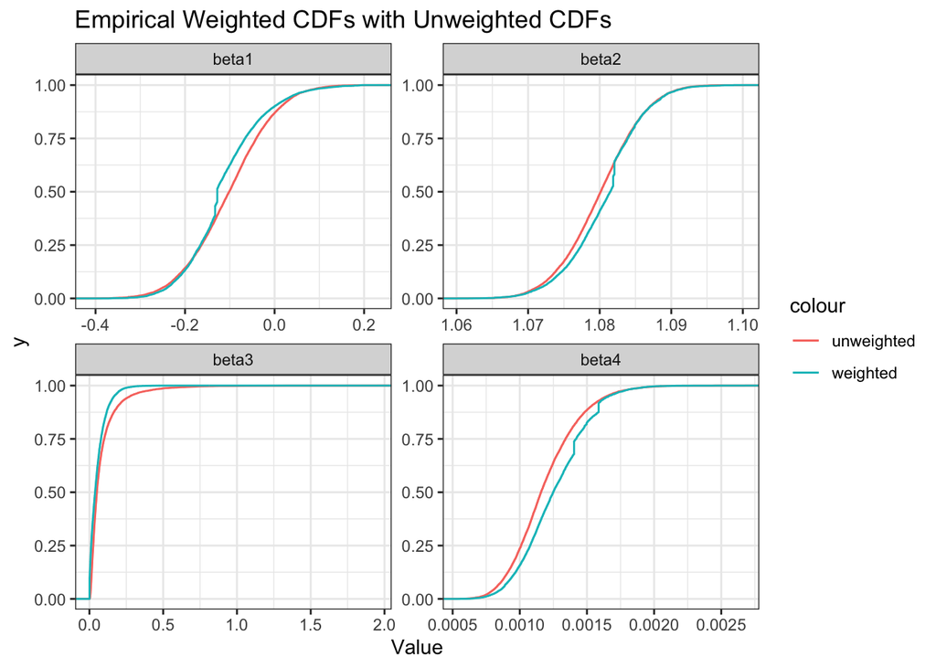

```r
  suppressWarnings({

  library(ggplot2)
  library(tidyr)

  # ggplot the weighted and unweighted data
  p <- ggplot(imp_sample_long, aes(x = Value)) +
    stat_ecdf(aes(color = "unweighted")) +
    stat_ewcdf(aes(weights = exp(log_weights), color = "weighted")) +
    facet_wrap(vars(Name),  scales = "free") +
    ggtitle("Empirical Weighted CDFs with Unweighted CDFs")

  print(p)

})
```

Looking at the plot above, the ECDFs for beta1, beta2, and beta4 are smoother and more linear compared to beta3, suggesting that these parameters are closer to a normal distribution and beta3 a distinctly right-skewed shape, indicating that its distribution is skewed towards higher value. These results correspond to the previous table, which is expected.